# Guía 2 - Ejercicio 8

8. Efectúe una clasificación por LDA de los datos abalone.txt, discriminando entre adulto e infante, utilizando aquellas variables que considere más pertinenes. Elija el mejor modelo, usando criterio, sentido común y alguno de los métdos propuestos vistos en clase para determinarlo. Se recomienda separar inicialmente un 20 %, 30 % de lo datos para poder hacer la evaluación final a través de una matriz de confusión. Antes que nada, se cargará el dataset con el que se trabajará:

```r
library(MASS)
library("dplyr")
library("ggpubr")
# Cargo los datos
mydata<-read.table("abalone.txt", sep=",", col.names=c("Género", "Longitud", "Diámetro","Altura","Peso completo","Peso Carne","Peso Vísceras","Peso Caparazón","Anillos"))
```

Visualicemos la estructura de estos datos:

|  | Género | Longitud | Diámetro | Altura | Peso.completo | Peso.Carne | Peso.Vísceras | Peso.Caparazón | Anillos |
| --- | --- | --- | --- | --- | --- | --- | --- | --- | --- |
| 1 | M | 0.455 | 0.365 | 0.095 | 0.5140 | 0.2245 | 0.1010 | 0.150 | 15 |
| 2 | M | 0.350 | 0.265 | 0.090 | 0.2255 | 0.0995 | 0.0485 | 0.070 | 7 |
| 3 | F | 0.530 | 0.420 | 0.135 | 0.6770 | 0.2565 | 0.1415 | 0.210 | 9 |
| 4 | M | 0.440 | 0.365 | 0.125 | 0.5160 | 0.2155 | 0.1140 | 0.155 | 10 |
| 5 | I | 0.330 | 0.255 | 0.080 | 0.2050 | 0.0895 | 0.0395 | 0.055 | 7 |
| 6 | I | 0.425 | 0.300 | 0.095 | 0.3515 | 0.1410 | 0.0775 | 0.120 | 8 |

Agreguemos ahora una columna que contenga la categoría “Adulto” o “Infante”. La misma se calculará a partir de la columna “Género”. Si es “F” o “M” será “A” de adulto. Si es “I” se dejará “I”.

```r
summary(mydata)
```

```
 Género      Longitud        Diámetro          Altura       Peso.completo      Peso.Carne
 F:1307   Min.   :0.075   Min.   :0.0550   Min.   :0.0000   Min.   :0.0020   Min.   :0.0010
 I:1342   1st Qu.:0.450   1st Qu.:0.3500   1st Qu.:0.1150   1st Qu.:0.4415   1st Qu.:0.1860
 M:1528   Median :0.545   Median :0.4250   Median :0.1400   Median :0.7995   Median :0.3360
          Mean   :0.524   Mean   :0.4079   Mean   :0.1395   Mean   :0.8287   Mean   :0.3594
          3rd Qu.:0.615   3rd Qu.:0.4800   3rd Qu.:0.1650   3rd Qu.:1.1530   3rd Qu.:0.5020
          Max.   :0.815   Max.   :0.6500   Max.   :1.1300   Max.   :2.8255   Max.   :1.4880
 Peso.Vísceras    Peso.Caparazón      Anillos         Adulto
 Min.   :0.0005   Min.   :0.0015   Min.   : 1.000   Mode :logical
 1st Qu.:0.0935   1st Qu.:0.1300   1st Qu.: 8.000   FALSE:1342
 Median :0.1710   Median :0.2340   Median : 9.000   TRUE :2835
 Mean   :0.1806   Mean   :0.2388   Mean   : 9.934
 3rd Qu.:0.2530   3rd Qu.:0.3290   3rd Qu.:11.000
 Max.   :0.7600   Max.   :1.0050   Max.   :29.000
```

|  | Género | Longitud | Diámetro | Altura | Peso.completo | Peso.Carne | Peso.Vísceras | Peso.Caparazón | Anillos | Adulto |
| --- | --- | --- | --- | --- | --- | --- | --- | --- | --- | --- |
| 1 | M | 0.455 | 0.365 | 0.095 | 0.5140 | 0.2245 | 0.1010 | 0.150 | 15 | TRUE |
| 2 | M | 0.350 | 0.265 | 0.090 | 0.2255 | 0.0995 | 0.0485 | 0.070 | 7 | TRUE |
| 3 | F | 0.530 | 0.420 | 0.135 | 0.6770 | 0.2565 | 0.1415 | 0.210 | 9 | TRUE |
| 4 | M | 0.440 | 0.365 | 0.125 | 0.5160 | 0.2155 | 0.1140 | 0.155 | 10 | TRUE |
| 5 | I | 0.330 | 0.255 | 0.080 | 0.2050 | 0.0895 | 0.0395 | 0.055 | 7 | FALSE |
| 6 | I | 0.425 | 0.300 | 0.095 | 0.3515 | 0.1410 | 0.0775 | 0.120 | 8 | FALSE |

El siguiente paso es corroborar las suposiciones sobre las que se basa el método de LDA. Ellas son:

- Normalidad de las variables
- Homogeneidad de la varianza
- Incorrelación de los predictores
- Independencia de las observaciones

## Normalidad de las variables

Vamos a aplicar dos métodos para verificar la normalidad de las variables:

- qqplot: inspección visual
- Lilliefors: Similar al método de Kolmogorov-Smirnov pero cuando se desconocen media y desvío estandar.

El método de Shapiro-Wilk no se aplicará ya que está recomendado para menos de 50 observaciones.  
Si bien el método de Kolmogorov-Smirnov (K-S) está recomendado para más de 50 observaciones, darpara aplicarlo lo mejor es conocer la media y el desvío estandar y no sus estimaciones.

Las variables que se van a considerar en principio son todas, es decir:

Longitud, Diámetro, Altura, Peso Completo, Peso Carne, Peso Vísceras, Peso Caparazón, Anillos

Empecemos analizando la variable Longitud:

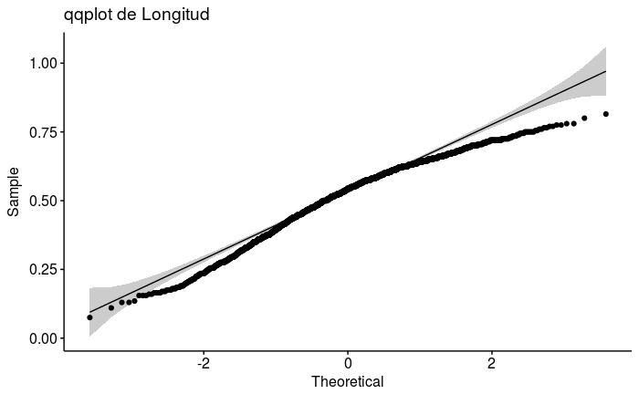

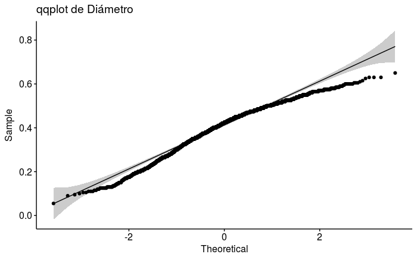

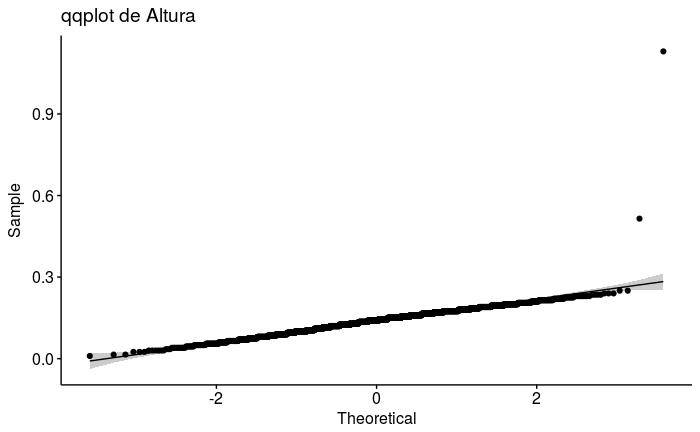

```r
ggqqplot(train$Longitud,main = "qqplot de Longitud")
ggqqplot(train$Diámetro,main = "qqplot de Diámetro")

ggqqplot(train$Altura,main = "qqplot de Altura")
```

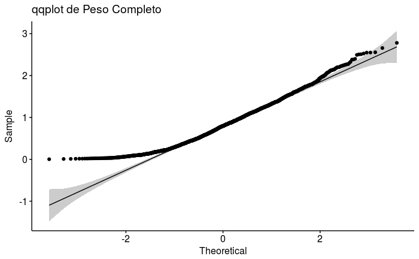

```r
ggqqplot(train$Peso.completo ,main = "qqplot de Peso Completo")
```

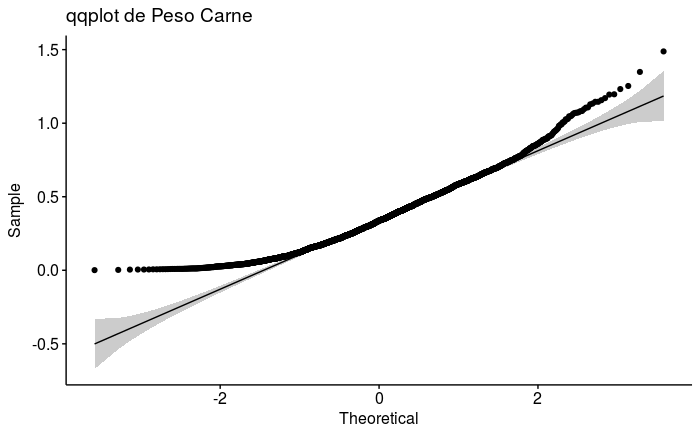

```r
ggqqplot(train$Peso.Carne,main = "qqplot de Peso Carne")
```

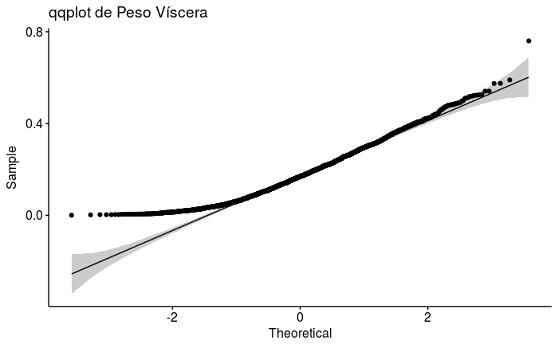

```r
ggqqplot(train$Peso.Víscera,main = "qqplot de Peso Víscera")
```

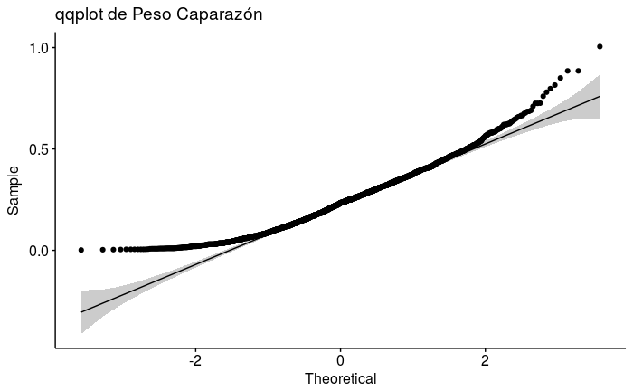

```r
ggqqplot(train$Peso.Caparazón,main = "qqplot de Peso Caparazón")
```

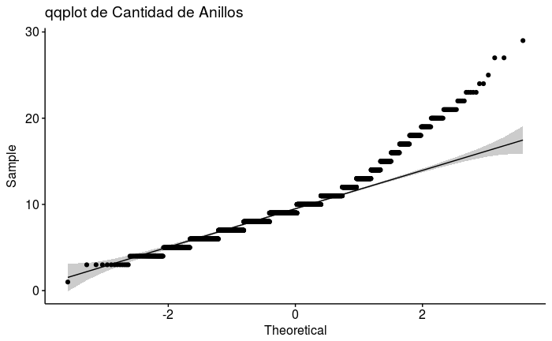

```r
ggqqplot(train$Anillos,main = "qqplot de Cantidad de Anillos")
```

```r
lillie.test(train$Longitud)
```

```
    Lilliefors (Kolmogorov-Smirnov) normality test

data:  train$Longitud
D = 0.073756, p-value < 2.2e-16
```

```r
lillie.test(train$Diámetro)
```

```
    Lilliefors (Kolmogorov-Smirnov) normality test

data:  train$Diámetro
D = 0.075032, p-value < 2.2e-16
```

```r
lillie.test(train$Altura)
```

```
    Lilliefors (Kolmogorov-Smirnov) normality test

data:  train$Altura
D = 0.052729, p-value < 2.2e-16
```

```r
lillie.test(train$Peso.completo)
```

```
    Lilliefors (Kolmogorov-Smirnov) normality test

data:  train$Peso.completo
D = 0.049124, p-value < 2.2e-16
```

```r
lillie.test(train$Peso.Carne)
```

```
    Lilliefors (Kolmogorov-Smirnov) normality test

data:  train$Peso.Carne
D = 0.055441, p-value < 2.2e-16
```

```r
lillie.test(train$Peso.Vísceras)
```

```
    Lilliefors (Kolmogorov-Smirnov) normality test

data:  train$Peso.Vísceras
D = 0.05396, p-value < 2.2e-16
```

```r
lillie.test(train$Peso.Caparazón)
```

```
    Lilliefors (Kolmogorov-Smirnov) normality test

data:  train$Peso.Caparazón
D = 0.047887, p-value < 2.2e-16
```

```r
lillie.test(train$Anillos)
```

```
    Lilliefors (Kolmogorov-Smirnov) normality test

data:  train$Anillos
D = 0.14647, p-value < 2.2e-16
```

Todos los p-value están muy por debajo del valor de corte de 0.05, el cual es el que debe ser superado para poder suponer normalidad. Si bien no se cumple la condición de normalidad, seguiremos adelante con el método ya que muchas veces da buenos resultados sin cumplir esta condición.